# Attempting to Evaluate Effectivness of MLB Fastballs

#### Chris Ribaudo

Hello to you reading this and welcome to my data science tutorial. The aim of this project is to provide a thorough and in depth tutorial on the data science pipeline, all the way from Data Collection through to Machine Learning with many stops in between.

The tutorial will also act as an investigation into the varying factors that have an association with the effectiveness of Fastballs thrown by Major League Baseball pitchers, and an attempt to model a fastball's effectiveness based on these factors.

From an investigative standpoint, the aim of this project is to create an accurate model for assessing the effectiveness of a Major League Fastball so that teams and pitchers may use the model to make more informed decisions and have more thorough and adaquete game planning and preparation, and increase overall pitcher success.

From this tutorial the reader will learn the necessary steps required for basic and thorough data science analysis. The tutorial will be loosely structured as follows:

- Data Collection
- Data Filtering, Curation, and Cleaning
- Exploratory Data Analysis
- Machine Learning
- Discussion of Results

To start with let's talk about the necessary tools you'll need to have installed on your computer or available to you if you want to replicate this investigation.

## Necessary Packages and Modules

We will be using the pybaseball module provided by James LeDoux and maintained by Moshe Schorr. It is a python package that provides us with easy ways to scrape baseball data from a variety of websites like [FanGraphs](https://www.fangraphs.com/), [Baseball Reference](https://www.baseball-reference.com/), and [Baseball Savant](https://baseballsavant.mlb.com/)

We don't have to use this package of course and could manually scrape the data ourselves, but this package makes it a lot easier and quicker to do, so we will be using it in this tutorial. If you want to learn more about the pybaseball package and what all you can do with it, here is its [Official GitHub Page](https://github.com/jldbc/pybaseball)

In order to use pybaseball you first have to install it onto your computer. In addition to pybaseball we will be using a few other Python packages as well like [Pandas](https://pandas.pydata.org/), [Seaborn](https://seaborn.pydata.org/), [Matplotlib](https://matplotlib.org/), and [SciKit-Learn](https://scikit-learn.org/stable/). Before importing any of these you need to have these installed on your computer, or in your active environment as well, so make sure that they are installed.

If you don't know how to install any of these packages or tools, their respective webpages have great guides for doing so and are linked above. If you also want to learn more about what you can do with these packages and all of their capabilities their websites also prove very useful.

Without further let's begin by importing all of the necessary packages and tools we will be using!

```python
import sys
!{sys.executable} -m pip install pybaseball #installing pybaseball in python site-packages used by current notebook

import pybaseball
import pandas as pd
import seaborn as sns
import matplotlib.pyplot as plt
import matplotlib.patches as patches
from sklearn import tree
from sklearn.preprocessing import LabelEncoder
from sklearn.model_selection import train_test_split
```

# Getting the Data

The first step in any data science process once you define your problem and understand what you want to examine, is to get the data.

For this tutorial data we will be using is MLB Statcast data. Statcast is an automated system that uses high speed cameras and radar in order to get a lot of advanced data on every single MLB player, pitch, and play.

Some of statcasts more popular measurements are the exit velocity of a baseball (how hard it is hit off the bat in Miles per Hour), sprint speed of a player, catch probability, pitch break (how much a pitch moves in feet compared to league average), spin rate of a pitch, and hundreds of others. If you want to read more about statcast here is its [Wikipedia page](https://en.wikipedia.org/wiki/Statcast) and the official [Statcast Glossary](http://m.mlb.com/glossary/statcast).

The pybaseball package allows us easily scrape Statcast data from any time frame, giving us data from every single pitch in every single game in the timeframe.

In any given MLB game there's about 300 pitches thrown, and in every full MLB regular season there are 162 games per 30 teams. So there's a total of 2430 games of about 300 pitches each, meaning that if we pull Statcast data from a full regular season we'd have over 700,000 rows of data! In addition, the data pulled from Statcast contains nearly 100 columns, meaning that a full season's worth of Statcast data would give us almost 70 million data values.

That's a lot of data, infact depending on how much memory each of those data values takes up, it might be over 500MB worth of data, maybe even an entire GigaByte. So in order to deal with this we'll instead only pull half a season's worth of data. At the time of writing it is currently May 2021, so the most recent half season of data available is the second half of the 2019 season (as the 2020 season was modified due to the Coronavirus Pandemic). So we will be getting our data from July 11th 2019 (the first game after the all-starbreak, marking the beginning of the second half of the season) through September 30th 2019 (the last day of the regular season).

It's still over 300,000 different pitches so we have plenty of data to work with, but won't take up quite as much meomory or time to get and maintain as a full season's worth of data would. So without further ado let's get this Statcast data. Pybaseball makes it very simple to do so with just one line of code.

It may take a few minutes to get all of the data, so just be patient.

```python
#enabling cache incase some type of interrupt or disconnect happens, making it easier/quicker to recover data (optional)
pybaseball.cache.enable()

#getting the data
data = pybaseball.statcast('2019-07-11', '2019-09-30')
```

```
This is a large query, it may take a moment to complete
```

Ok so we have the data! Let's take a look at it

```python
data.head()
```

|  | pitch_type | game_date | release_speed | release_pos_x | release_pos_z | player_name | batter | pitcher | events | description | ... | fld_score | post_away_score | post_home_score | post_bat_score | post_fld_score | if_fielding_alignment | of_fielding_alignment | spin_axis | delta_home_win_exp | delta_run_exp |
| --- | --- | --- | --- | --- | --- | --- | --- | --- | --- | --- | --- | --- | --- | --- | --- | --- | --- | --- | --- | --- | --- |
| 2099 | FC | 2019-09-29 | 91.1 | -2.16 | 6.08 | Herrera, Kelvin | 641513 | 516969 | strikeout | swinging_strike | ... | 5 | 3 | 5 | 3 | 5 | Standard | Standard | 187 | 0.011 | -0.099 |
| 2133 | FC | 2019-09-29 | 88.2 | -2.22 | 6.07 | Herrera, Kelvin | 641513 | 516969 | None | foul | ... | 5 | 3 | 5 | 3 | 5 | Standard | Standard | 158 | 0.0 | -0.033 |
| 2261 | FF | 2019-09-29 | 95.8 | -1.55 | 6.41 | Herrera, Kelvin | 641513 | 516969 | None | ball | ... | 5 | 3 | 5 | 3 | 5 | Standard | Standard | 212 | 0.0 | 0.024 |
| 2280 | FC | 2019-09-29 | 90.1 | -2.16 | 6.01 | Herrera, Kelvin | 641513 | 516969 | None | ball | ... | 5 | 3 | 5 | 3 | 5 | Standard | Standard | 159 | 0.0 | 0.012 |
| 2379 | FF | 2019-09-29 | 98.2 | -1.47 | 6.24 | Herrera, Kelvin | 641513 | 516969 | None | called_strike | ... | 5 | 3 | 5 | 3 | 5 | Standard | Standard | 196 | 0.0 | -0.019 |

5 rows × 92 columns

We've got data! Now that we've got the data, the next step is to examine it. Having some numbers and values is great and all, but before we do any analysis we need to filter our data so that we only include the information relevant to the interests of our study.

# Filtering and Curating the Data

Having data is good, but it's no use to waste memory storing a bunch of values that aren't useful to you. Additionally you might forget they are there and as a result could affect the results of any analysis you do later on down the road, so whenver you're working with data, it's important to filter out values and observations that aren't relevant to your study.

We only want to examine fastballs, and currently we have them, but we also curveballs, sliders, knuckleballs, even eephus pitches. Let's examine what are all the pitch types we have in the table

```python
print(data['pitch_name'].value_counts())
```

```
4-Seam Fastball    116735
Slider              56942
Changeup            36376
Curveball           29549
2-Seam Fastball     27632
Sinker              26455
Cutter              21625
Knuckle Curve        6881
Split-Finger         4725
Fastball              110
Knuckleball            16
Forkball               15
Eephus                 10
Name: pitch_name, dtype: int64
```

Ok so there's a lot of pitch types in our dataframe. The ones we care about are all the different kinds of fastballs. They are: '4-Seam Fastball', '2-Seam Fastball', 'Sinker', 'Cutter', and 'Split-Finger'. You'll notice that 'Fastball' is also displayed, however it occurs with such low frequency compared to the others that it seems to be the default encoding when statcast cannot decipher the pitch type, so it is more like 'Unknown', so as a result we will not be including it in our analysis.

If you want to read about what the other pitch types are, Fangraphs has a great primer [here](https://library.fangraphs.com/pitch-type-abbreviations-classifications/)

So let's subset our data so that our table only includes pitches that were fastballs.

```python
#Selecting entries only where the pitch type is a type of fastball
fastballs = data[data['pitch_name'].isin(['4-Seam Fastball', '2-Seam Fastball', 'Sinker', 'Cutter', 'Split-Finger'])]

fastballs.head()
```

|  | pitch_type | game_date | release_speed | release_pos_x | release_pos_z | player_name | batter | pitcher | events | description | ... | fld_score | post_away_score | post_home_score | post_bat_score | post_fld_score | if_fielding_alignment | of_fielding_alignment | spin_axis | delta_home_win_exp | delta_run_exp |
| --- | --- | --- | --- | --- | --- | --- | --- | --- | --- | --- | --- | --- | --- | --- | --- | --- | --- | --- | --- | --- | --- |
| 2099 | FC | 2019-09-29 | 91.1 | -2.16 | 6.08 | Herrera, Kelvin | 641513 | 516969 | strikeout | swinging_strike | ... | 5 | 3 | 5 | 3 | 5 | Standard | Standard | 187 | 0.011 | -0.099 |
| 2133 | FC | 2019-09-29 | 88.2 | -2.22 | 6.07 | Herrera, Kelvin | 641513 | 516969 | None | foul | ... | 5 | 3 | 5 | 3 | 5 | Standard | Standard | 158 | 0.0 | -0.033 |
| 2261 | FF | 2019-09-29 | 95.8 | -1.55 | 6.41 | Herrera, Kelvin | 641513 | 516969 | None | ball | ... | 5 | 3 | 5 | 3 | 5 | Standard | Standard | 212 | 0.0 | 0.024 |
| 2280 | FC | 2019-09-29 | 90.1 | -2.16 | 6.01 | Herrera, Kelvin | 641513 | 516969 | None | ball | ... | 5 | 3 | 5 | 3 | 5 | Standard | Standard | 159 | 0.0 | 0.012 |
| 2379 | FF | 2019-09-29 | 98.2 | -1.47 | 6.24 | Herrera, Kelvin | 641513 | 516969 | None | called_strike | ... | 5 | 3 | 5 | 3 | 5 | Standard | Standard | 196 | 0.0 | -0.019 |

5 rows × 92 columns

But we still have a bit too much data for the purposes of this study. We want to analyze how effective any given pitch is. However it's difficult to do that when the batter doesn't actually put the pitch into play so we want to only look at pitches where an event occured. Plays or events that we will use for analysis are plays where an at bat ended, these include a ball put in play, strikeouts, walks, and a few other events. So let's remove all rows where no event occured.

```python
#Plays where events occured
fastballs = fastballs[~fastballs['events'].isna()]

fastballs.head()
```

|  | pitch_type | game_date | release_speed | release_pos_x | release_pos_z | player_name | batter | pitcher | events | description | ... | fld_score | post_away_score | post_home_score | post_bat_score | post_fld_score | if_fielding_alignment | of_fielding_alignment | spin_axis | delta_home_win_exp | delta_run_exp |
| --- | --- | --- | --- | --- | --- | --- | --- | --- | --- | --- | --- | --- | --- | --- | --- | --- | --- | --- | --- | --- | --- |
| 2099 | FC | 2019-09-29 | 91.1 | -2.16 | 6.08 | Herrera, Kelvin | 641513 | 516969 | strikeout | swinging_strike | ... | 5 | 3 | 5 | 3 | 5 | Standard | Standard | 187 | 0.011 | -0.099 |
| 2570 | FT | 2019-09-29 | 98.3 | -1.67 | 6.32 | Herrera, Kelvin | 621514 | 516969 | strikeout | swinging_strike | ... | 5 | 3 | 5 | 3 | 5 | Infield shift | Standard | 214 | 0.023 | -0.125 |
| 3260 | FF | 2019-09-29 | 97.0 | -1.93 | 6.18 | Herrera, Kelvin | 500135 | 516969 | home_run | hit_into_play | ... | 5 | 3 | 5 | 3 | 5 | Standard | Standard | 185 | -0.021 | 0.947 |
| 4279 | FF | 2019-09-29 | 95.9 | -2.19 | 6.19 | Herrera, Kelvin | 543308 | 516969 | field_out | hit_into_play | ... | 5 | 2 | 5 | 2 | 5 | Standard | Standard | 187 | 0.018 | -0.248 |
| 2610 | SI | 2019-09-29 | 94.5 | -3.04 | 5.41 | Alcántara, Victor | 650391 | 622505 | grounded_into_double_play | hit_into_play | ... | 2 | 2 | 5 | 5 | 2 | Standard | Standard | 254 | -0.006 | -0.426 |

5 rows × 92 columns

Ok so now that's a bit better, we can see that the 'events' column no longer has any NaN (missing) values. Let's dig a bit deeper and see what are all the different kind of events that occured during the second half of the 2019 season.

```python
fastballs['events'].value_counts()
```

```
field_out                       19416
strikeout                        9598
single                           7220
walk                             4895
double                           2394
home_run                         2013
grounded_into_double_play         987
force_out                         932
hit_by_pitch                      595
field_error                       366
sac_fly                           304
sac_bunt                          243
triple                            233
fielders_choice                   117
double_play                       115
fielders_choice_out                75
caught_stealing_2b                 49
strikeout_double_play              36
catcher_interf                     18
pickoff_1b                          3
other_out                           2
caught_stealing_home                2
caught_stealing_3b                  2
game_advisory                       1
pickoff_3b                          1
sac_fly_double_play                 1
wild_pitch                          1
pickoff_2b                          1
pickoff_caught_stealing_home        1
sac_bunt_double_play                1
triple_play                         1
Name: events, dtype: int64
```

There's a wide variety of events, and while non of them are NaN like before, there's still some that we don't care about.

The whole purpose of this study remember is to evaluate the effectiveness of certain types of fastballs, namely whether or not a pitcher recorded an out with it, and if they didn't, what kind of way the batter reached base. Some of these events don't tell us any of this.

For example there were three pickoffs at first base, this was an event that happend, but the outcome wasn't due to the effectivness of the fastball, in fact the play that ocurred wasn't even a pitch! So we won't want to include these events in our analysis and so we'll remove them.

Another set of plays to remove would be caught stealings and sacrifice bunts. Caught stealings aren't helpful to us because the event refers to a play that the catcher made, and so the outcome is due to the catcher, not the fastball or pitcher. Sacrifice bunts are equally not useful because when a batter makes a sacrifice bunt, they are getting out on purpose in order to move the baserunners to the next base, so they didn't get out because the fastball thrown was a good pitch, they got out on purpose.

There are a few other kinds of plays we won't be including in our analysis for similar reasons, that the outcome doesn't tell us anything about the effectiveness of the pitch and is due entirely to other factors. So let's remove these rows from our table now.

```python
#strikeout = good pitch
#double = bad pitch
#error = good pitch (should have been an out)
#sac fly = good pitch
#Get rid of bunt because the batter got out on purpose, not because pitch was good/bad
#pickoffs also tell us nothing about pitch, same w/ game_advisory, caught stealing, and others

#Only keep these types of outcomes because they indicate the pitch had a good or bad outcome
outcomes = ['field_out', 'strikeout', 'single', 'walk', 'double', 'home_run', 'triple',
            'grounded_into_double_play', 'force_out', 'hit_by_pitch', 'field_error', 'sac_fly',
            'double_play', 'fielders_choice', 'fielders_choice_out', 'strikeout_double_play',
            'sac_fly_double_play', 'triple_play']

fastballs = fastballs[fastballs['events'].isin(outcomes)]

fastballs.head()
```

|  | pitch_type | game_date | release_speed | release_pos_x | release_pos_z | player_name | batter | pitcher | events | description | ... | fld_score | post_away_score | post_home_score | post_bat_score | post_fld_score | if_fielding_alignment | of_fielding_alignment | spin_axis | delta_home_win_exp | delta_run_exp |
| --- | --- | --- | --- | --- | --- | --- | --- | --- | --- | --- | --- | --- | --- | --- | --- | --- | --- | --- | --- | --- | --- |
| 2099 | FC | 2019-09-29 | 91.1 | -2.16 | 6.08 | Herrera, Kelvin | 641513 | 516969 | strikeout | swinging_strike | ... | 5 | 3 | 5 | 3 | 5 | Standard | Standard | 187 | 0.011 | -0.099 |
| 2570 | FT | 2019-09-29 | 98.3 | -1.67 | 6.32 | Herrera, Kelvin | 621514 | 516969 | strikeout | swinging_strike | ... | 5 | 3 | 5 | 3 | 5 | Infield shift | Standard | 214 | 0.023 | -0.125 |
| 3260 | FF | 2019-09-29 | 97.0 | -1.93 | 6.18 | Herrera, Kelvin | 500135 | 516969 | home_run | hit_into_play | ... | 5 | 3 | 5 | 3 | 5 | Standard | Standard | 185 | -0.021 | 0.947 |
| 4279 | FF | 2019-09-29 | 95.9 | -2.19 | 6.19 | Herrera, Kelvin | 543308 | 516969 | field_out | hit_into_play | ... | 5 | 2 | 5 | 2 | 5 | Standard | Standard | 187 | 0.018 | -0.248 |
| 2610 | SI | 2019-09-29 | 94.5 | -3.04 | 5.41 | Alcántara, Victor | 650391 | 622505 | grounded_into_double_play | hit_into_play | ... | 2 | 2 | 5 | 5 | 2 | Standard | Standard | 254 | -0.006 | -0.426 |

5 rows × 92 columns

Ok so now we have subsetted our fastballs to only include plays in which events happend that let us evaluate the successfulness of a pitcher, so now we can do some data analysis! Right?

Almost, but not quite. Our table is still pretty big, and a lot of it we don't need. Statcast has all this cool data provided for us, but for this study most of it we don't care about. We only care about some information about the pitch, the outcome, and the situation.

For the pitch we would like to know it's speed, location, spinrate, and type.

For the outcome we care about the event (home run, double, strikeout, etc), and the xwOBA (more on this in a bit).

Situationally we want to know the count (balls and strikes).

Now to explain xwOBA. Baseball has a bunch of batting statistics like batting percentage, slugging percentage, on-base percentage, and others. wOBA (Weighted On-Base Average) is another one of them and is one of the best ways to assess a batter's or pitcher's performance using a single statistic. It's calculation is a bit contrived so I won't get too into it here, but if you want to learn more about it, and the formula for calculating it, Fangraphs has an [excellent explanation](https://library.fangraphs.com/offense/woba/) on it.

The main idea is as follows: For a batter getting on base is good, and getting out is bad. But not all ways of getting on base are equal. A home run is better than a single, and a single is better than a walk. So let's weight each outcome to accurately reflect this.

For batters a higher wOBA is better, and naturally for pitchers a lower wOBA is better (as it's the wOBA they gave up to batters). As a reference, for hitters an average wOBA is 0.320, a great wOBA is 0.370, and a poor wOBA is 0.300. For pitchers the values are the same but reversed, so an average wOBA is 0.320, a great wOBA is 0.300, and a poor wOBA is 0.370.

However I've only explained wOBA, and not xwOBA. xwOBA just means Expected wOBA. Sometimes batters hit a ball really hard, but right at a fielder so even though they hit the ball hard, they still got out. Similarly somtimes they can really weakly hit a ball but it just so happens to fall in the middle of nowhere between fielders so they get a hit. xwOBA is able to accurately reflect this so that the luck involved in where the fielders are (which is out of the batter's control) is accounted for.

Generally for a batter hitting the ball hard is good, and hitting it soft is bad. You also don't want to hit the ball straight into the ground or straight up, you kind of want to hit it inbetween so that it's a nice long line drive and will go as far as possible.

One of the things that Statcast can calculate for every ball that a batter hits is its exit velocity and launch angle. These are just fancy terms meaning how hard a batter hit the ball and in what direction e.g up, down, inbetween. Using these values Statcast can calculate the Expected wOBA of each hit based on how well the ball was it, this way it elimates the luck involved in hitting it directly at the fielders or far away from them.

So xwOBA is a really accurate way to assess the quality and effectivness of a pitch (with a lower xwOBA meaning a better pitch). We will be using xwOBA as a measure to assess exactly how effective any given pitch is. It's not a perfect system and definitely has its flaws, but is nonetheless one of the better ways to examine pitch effectiveness using a single statistic.

If you would like to read about xwOBA more, or if my explanation wasn't very clear here is a [great explanation](http://m.mlb.com/glossary/statcast/expected-woba) by MLB.

So let's reduce our dataframe to only include these columns we care about.

```python
#Just keep columns we care about
columns = ['release_speed', 'events', 'zone', 'balls', 'strikes',
           'plate_x', 'plate_z', 'release_spin_rate', 'estimated_woba_using_speedangle', 'pitch_name']

fastballs = fastballs[columns]

#Renaming xWOBA column
fastballs.rename(columns={'estimated_woba_using_speedangle': 'xwOBA'}, inplace=True)

fastballs.head()
```

|  | release_speed | events | zone | balls | strikes | plate_x | plate_z | release_spin_rate | xwOBA | pitch_name |
| --- | --- | --- | --- | --- | --- | --- | --- | --- | --- | --- |
| 2099 | 91.1 | strikeout | 14 | 2 | 2 | 0.08 | 1.02 | 2347 | <NA> | Cutter |
| 2570 | 98.3 | strikeout | 1 | 1 | 2 | -0.82 | 2.84 | 2268 | <NA> | 2-Seam Fastball |
| 3260 | 97.0 | home_run | 4 | 3 | 2 | -0.68 | 2.39 | 2252 | 1.281 | 4-Seam Fastball |
| 4279 | 95.9 | field_out | 12 | 0 | 0 | 0.11 | 3.73 | 2251 | 0.006 | 4-Seam Fastball |
| 2610 | 94.5 | grounded_into_double_play | 6 | 2 | 1 | 0.4 | 2.29 | 2206 | 0.144 | Sinker |

Ok great now our table is much smaller (and takes up less memory on our computers which is nice) and we only have relevant information stored in it.

While we're fixing up our table let's fix the indexing on it. It currently has the first entry as '2099' and the second as '2570', this doesn't make much sense, so let's renumber them 0, 1, 2, etc

```python
#reset index and then drop the new column created from it
fastballs = fastballs.reset_index().drop(columns='index')

fastballs.head()
```

|  | release_speed | events | zone | balls | strikes | plate_x | plate_z | release_spin_rate | xwOBA | pitch_name |
| --- | --- | --- | --- | --- | --- | --- | --- | --- | --- | --- |
| 0 | 91.1 | strikeout | 14 | 2 | 2 | 0.08 | 1.02 | 2347 | <NA> | Cutter |
| 1 | 98.3 | strikeout | 1 | 1 | 2 | -0.82 | 2.84 | 2268 | <NA> | 2-Seam Fastball |
| 2 | 97.0 | home_run | 4 | 3 | 2 | -0.68 | 2.39 | 2252 | 1.281 | 4-Seam Fastball |
| 3 | 95.9 | field_out | 12 | 0 | 0 | 0.11 | 3.73 | 2251 | 0.006 | 4-Seam Fastball |
| 4 | 94.5 | grounded_into_double_play | 6 | 2 | 1 | 0.4 | 2.29 | 2206 | 0.144 | Sinker |

Much better. Now we have a small and readable table of values. However we can see some issues. Look at the first two entries in the xwOBA column, they're empty!

## Dealing with Missing Values

It's always important before doing any type of data analysis to check to see if you have any missing values, as these can throw off the results of many popular data science and machine learning algorithms, as well as affecting what your plots and figures might look like. If there are missing values these need to be examined and dealt with in an appropriate manner. There is no one size fits all method for dealing with missing values so its best to examine them and decide for yourself how to proceed. Let's do that with our data now.

We can see that both of these missing entries corresponded to strikeouts. This makes sense. On a strikeout, a batter doesn't hit the ball, this means that there was no exit velocity or launch angle on the pitch to calculate the xwOBA from, so of course it's missing!

We can fix this by going through the table and changing xwOBA entries that are empty and corresponded to a strikeout to have an xwOBA of zero.

If you're wondering why it's zero, you can think of it as the batter is guaranteed to get out when they strikeout, and a value of zero reflects this. In fact all strikeouts do have an wOBA of zero (and have to by definition of what they are), so they're xwOBA should also be zero.

Let's fix these entries now.

```python
#changing xwOBAs to zero if it was a strikeout

#go through each row in the dataframe
for idx, row in fastballs.iterrows():
    #if xwOBA is empty and event was a strikeout
    if pd.isna(row.loc['xwOBA']) and row.loc['events'] == 'strikeout':
        #set xwOBA to zero
        fastballs.loc[idx, 'xwOBA'] = 0

fastballs.head()
```

|  | release_speed | events | zone | balls | strikes | plate_x | plate_z | release_spin_rate | xwOBA | pitch_name |
| --- | --- | --- | --- | --- | --- | --- | --- | --- | --- | --- |
| 0 | 91.1 | strikeout | 14 | 2 | 2 | 0.08 | 1.02 | 2347 | 0.0 | Cutter |
| 1 | 98.3 | strikeout | 1 | 1 | 2 | -0.82 | 2.84 | 2268 | 0.0 | 2-Seam Fastball |
| 2 | 97.0 | home_run | 4 | 3 | 2 | -0.68 | 2.39 | 2252 | 1.281 | 4-Seam Fastball |
| 3 | 95.9 | field_out | 12 | 0 | 0 | 0.11 | 3.73 | 2251 | 0.006 | 4-Seam Fastball |
| 4 | 94.5 | grounded_into_double_play | 6 | 2 | 1 | 0.4 | 2.29 | 2206 | 0.144 | Sinker |

Alright that looks a lot better! However we're not out of the woods just yet, there still might be other missing values in our dataframe that we can fix.

Let's look at how many missing values we still have.

```python
#Sum up number of missing values in each column
fastballs.isna().sum()
```

```
release_speed          56
events                  0
zone                   56
balls                   0
strikes                 0
plate_x                56
plate_z                56
release_spin_rate     242
xwOBA                5700
pitch_name              0
dtype: int64
```

So it looks like we still have a bunch of missing values in the xwOBA column. Let's look at what these rows look like.

```python
#show rows where xwOBA is empty
fastballs[fastballs['xwOBA'].isna()]
```

|  | release_speed | events | zone | balls | strikes | plate_x | plate_z | release_spin_rate | xwOBA | pitch_name |
| --- | --- | --- | --- | --- | --- | --- | --- | --- | --- | --- |
| 5 | 90.8 | hit_by_pitch | 14 | 1 | 0 | 2.47 | 0.04 | 1715 | <NA> | Sinker |
| 17 | 95.2 | walk | 11 | 3 | 2 | -1.35 | 3.24 | 2437 | <NA> | 4-Seam Fastball |
| 20 | 97.7 | walk | 13 | 3 | 2 | -0.54 | 1.04 | 2092 | <NA> | Sinker |
| 21 | 90.5 | single | 2 | 0 | 0 | 0.0 | 3.33 | 2229 | <NA> | 4-Seam Fastball |
| 31 | 95.9 | hit_by_pitch | 11 | 2 | 0 | -1.94 | 3.77 | 2169 | <NA> | Sinker |
| ... | ... | ... | ... | ... | ... | ... | ... | ... | ... | ... |
| 49284 | 90.7 | walk | 14 | 3 | 1 | 1.46 | 1.81 | 2612 | <NA> | Cutter |
| 49287 | 93.9 | walk | 11 | 3 | 0 | -0.18 | 3.81 | 2241 | <NA> | 4-Seam Fastball |
| 49288 | 91.7 | walk | 8 | 3 | 1 | -0.03 | 1.54 | 2220 | <NA> | 2-Seam Fastball |
| 49293 | 94.6 | walk | 12 | 3 | 1 | 1.15 | 2.92 | 2260 | <NA> | 4-Seam Fastball |
| 49295 | 95.4 | walk | 14 | 3 | 0 | 1.19 | 1.81 | 2556 | <NA> | 4-Seam Fastball |

5700 rows × 10 columns

Ok so we can see that a lot of these missing values correspond to walks and hit by pitches. Which, just like the strikeouts make sense! Afterall on both a walk and a hit by pitch, the batter dosn't actually hit the ball so there's no exit velocity and launch angle to calculate the xwOBA from.

So let's manually input each of these values into our dataframe just like we did with strikeouts before. Except instead of inputting them as zero, we'll input them as 0.69 for walks, and 0.72 for hit_by_pitch. If you're wondering where these values are coming from they are based on the formula shown on the Fangraphs wOBA page. I linked it above but for convenience will link it again [here](https://library.fangraphs.com/offense/woba/).

The formula shown is for wOBA and not xwOBA, but just like with strikeouts, a walk is always a walk and a hit by pitch is always a hit by pitch, regardless of luck, so there's no variance in outcomes due to fielders and wind and other factors like there are for balls that are hit, so a walk is always expected to have a 0.69

I should note however, that 0.69 and 0.72 are not exact, as depending on factors that influence the run environment (how frequently runs are scored) like the stadium, time of day, year, etc, the values might change slightly, but they are very close and we can go ahead and use them as the changes to the values are generally very small. This is mentioned in the Fangraphs page linked above.

So let's fix these values here.

```python
#changing xwOBAs for walks and hit by pitch

#go through each row in the dataframe
for idx, row in fastballs.iterrows():
    #if xwOBA is empty
    if pd.isna(row.loc['xwOBA']):
        if row.loc['events'] == 'walk':
            #set xwOBA to 0.69
            fastballs.loc[idx, 'xwOBA'] = 0.69

        if row.loc['events'] == 'hit_by_pitch':
            #set xwOBA to 0.72
            fastballs.loc[idx, 'xwOBA'] = 0.72
```

Now let's check if we have any other missing values still

```python
#Sum up number of missing values in each column
fastballs.isna().sum()
```

```
release_speed         56
events                 0
zone                  56
balls                  0
strikes                0
plate_x               56
plate_z               56
release_spin_rate    242
xwOBA                210
pitch_name             0
dtype: int64
```

That's a lot less missing values now. Interestingly four of the columns have the exact same number of missing entries. It's likely they're all in the same set of rows. Let's check.

```python
#rows where release speed is missing
fastballs[fastballs['release_speed'].isna()]
```

|  | release_speed | events | zone | balls | strikes | plate_x | plate_z | release_spin_rate | xwOBA | pitch_name |
| --- | --- | --- | --- | --- | --- | --- | --- | --- | --- | --- |
| 22093 | <NA> | field_out | <NA> | 3 | 2 | <NA> | <NA> | <NA> | <NA> | 4-Seam Fastball |
| 22094 | <NA> | hit_by_pitch | <NA> | 2 | 1 | <NA> | <NA> | <NA> | 0.72 | Split-Finger |
| 22095 | <NA> | field_out | <NA> | 3 | 2 | <NA> | <NA> | <NA> | <NA> | 4-Seam Fastball |
| 22096 | <NA> | strikeout | <NA> | 2 | 2 | <NA> | <NA> | <NA> | 0.0 | Split-Finger |
| 22097 | <NA> | strikeout | <NA> | 3 | 2 | <NA> | <NA> | <NA> | 0.0 | 4-Seam Fastball |
| 22098 | <NA> | double | <NA> | 3 | 2 | <NA> | <NA> | <NA> | <NA> | Sinker |
| 22099 | <NA> | strikeout | <NA> | 1 | 2 | <NA> | <NA> | <NA> | 0.0 | 4-Seam Fastball |
| 22100 | <NA> | strikeout | <NA> | 2 | 2 | <NA> | <NA> | <NA> | 0.0 | 4-Seam Fastball |
| 22101 | <NA> | field_out | <NA> | 0 | 0 | <NA> | <NA> | <NA> | <NA> | 2-Seam Fastball |
| 22102 | <NA> | walk | <NA> | 3 | 2 | <NA> | <NA> | <NA> | 0.69 | 4-Seam Fastball |
| 22103 | <NA> | field_out | <NA> | 0 | 1 | <NA> | <NA> | <NA> | <NA> | 4-Seam Fastball |
| 22104 | <NA> | force_out | <NA> | 1 | 1 | <NA> | <NA> | <NA> | <NA> | 2-Seam Fastball |
| 22105 | <NA> | walk | <NA> | 3 | 1 | <NA> | <NA> | <NA> | 0.69 | 2-Seam Fastball |
| 22106 | <NA> | home_run | <NA> | 0 | 0 | <NA> | <NA> | <NA> | <NA> | 2-Seam Fastball |
| 22107 | <NA> | walk | <NA> | 3 | 0 | <NA> | <NA> | <NA> | 0.69 | 4-Seam Fastball |
| 22108 | <NA> | field_out | <NA> | 0 | 2 | <NA> | <NA> | <NA> | <NA> | 2-Seam Fastball |
| 22109 | <NA> | single | <NA> | 1 | 2 | <NA> | <NA> | <NA> | <NA> | 2-Seam Fastball |
| 22110 | <NA> | field_out | <NA> | 1 | 0 | <NA> | <NA> | <NA> | <NA> | 2-Seam Fastball |
| 22111 | <NA> | strikeout | <NA> | 3 | 2 | <NA> | <NA> | <NA> | 0.0 | 4-Seam Fastball |
| 22112 | <NA> | walk | <NA> | 3 | 1 | <NA> | <NA> | <NA> | 0.69 | 4-Seam Fastball |
| 22113 | <NA> | force_out | <NA> | 1 | 0 | <NA> | <NA> | <NA> | <NA> | 2-Seam Fastball |
| 22114 | <NA> | single | <NA> | 0 | 1 | <NA> | <NA> | <NA> | <NA> | 4-Seam Fastball |
| 22115 | <NA> | force_out | <NA> | 2 | 2 | <NA> | <NA> | <NA> | <NA> | 2-Seam Fastball |
| 22116 | <NA> | single | <NA> | 0 | 0 | <NA> | <NA> | <NA> | <NA> | 2-Seam Fastball |
| 22117 | <NA> | field_out | <NA> | 1 | 2 | <NA> | <NA> | <NA> | <NA> | 4-Seam Fastball |
| 22118 | <NA> | strikeout | <NA> | 0 | 2 | <NA> | <NA> | <NA> | 0.0 | 4-Seam Fastball |
| 22119 | <NA> | field_out | <NA> | 2 | 2 | <NA> | <NA> | <NA> | <NA> | 4-Seam Fastball |
| 22120 | <NA> | double | <NA> | 0 | 0 | <NA> | <NA> | <NA> | <NA> | 4-Seam Fastball |
| 22121 | <NA> | field_out | <NA> | 3 | 2 | <NA> | <NA> | <NA> | <NA> | 2-Seam Fastball |
| 22122 | <NA> | field_out | <NA> | 2 | 1 | <NA> | <NA> | <NA> | <NA> | 2-Seam Fastball |
| 22123 | <NA> | field_out | <NA> | 1 | 1 | <NA> | <NA> | <NA> | <NA> | 4-Seam Fastball |
| 22124 | <NA> | double | <NA> | 2 | 2 | <NA> | <NA> | <NA> | <NA> | 4-Seam Fastball |
| 22125 | <NA> | walk | <NA> | 3 | 0 | <NA> | <NA> | <NA> | 0.69 | 4-Seam Fastball |
| 22126 | <NA> | walk | <NA> | 3 | 0 | <NA> | <NA> | <NA> | 0.69 | 4-Seam Fastball |
| 22127 | <NA> | home_run | <NA> | 1 | 0 | <NA> | <NA> | <NA> | <NA> | Cutter |
| 22128 | <NA> | strikeout | <NA> | 2 | 2 | <NA> | <NA> | <NA> | 0.0 | 4-Seam Fastball |
| 22129 | <NA> | single | <NA> | 1 | 0 | <NA> | <NA> | <NA> | <NA> | Cutter |
| 22130 | <NA> | strikeout | <NA> | 2 | 2 | <NA> | <NA> | <NA> | 0.0 | 2-Seam Fastball |
| 22131 | <NA> | field_out | <NA> | 1 | 1 | <NA> | <NA> | <NA> | <NA> | 2-Seam Fastball |
| 22132 | <NA> | hit_by_pitch | <NA> | 1 | 1 | <NA> | <NA> | <NA> | 0.72 | 2-Seam Fastball |
| 22133 | <NA> | field_out | <NA> | 1 | 2 | <NA> | <NA> | <NA> | <NA> | 2-Seam Fastball |
| 22134 | <NA> | grounded_into_double_play | <NA> | 1 | 0 | <NA> | <NA> | <NA> | <NA> | 4-Seam Fastball |
| 22135 | <NA> | walk | <NA> | 3 | 1 | <NA> | <NA> | <NA> | 0.69 | 4-Seam Fastball |
| 22136 | <NA> | field_out | <NA> | 0 | 0 | <NA> | <NA> | <NA> | <NA> | 4-Seam Fastball |
| 22137 | <NA> | double | <NA> | 2 | 2 | <NA> | <NA> | <NA> | <NA> | 4-Seam Fastball |
| 22138 | <NA> | field_out | <NA> | 2 | 1 | <NA> | <NA> | <NA> | <NA> | 2-Seam Fastball |
| 22139 | <NA> | field_out | <NA> | 3 | 2 | <NA> | <NA> | <NA> | <NA> | 4-Seam Fastball |
| 22140 | <NA> | field_out | <NA> | 0 | 0 | <NA> | <NA> | <NA> | <NA> | 4-Seam Fastball |
| 22141 | <NA> | walk | <NA> | 3 | 0 | <NA> | <NA> | <NA> | 0.69 | 4-Seam Fastball |
| 22142 | <NA> | double | <NA> | 0 | 0 | <NA> | <NA> | <NA> | <NA> | 2-Seam Fastball |
| 22143 | <NA> | field_out | <NA> | 3 | 2 | <NA> | <NA> | <NA> | <NA> | Cutter |
| 22144 | <NA> | strikeout | <NA> | 2 | 2 | <NA> | <NA> | <NA> | 0.0 | 2-Seam Fastball |
| 22145 | <NA> | grounded_into_double_play | <NA> | 2 | 0 | <NA> | <NA> | <NA> | <NA> | 2-Seam Fastball |
| 22146 | <NA> | field_out | <NA> | 2 | 2 | <NA> | <NA> | <NA> | <NA> | 4-Seam Fastball |
| 22147 | <NA> | field_out | <NA> | 3 | 2 | <NA> | <NA> | <NA> | <NA> | 4-Seam Fastball |
| 44826 | <NA> | strikeout | <NA> | 0 | 2 | <NA> | <NA> | <NA> | 0.0 | 4-Seam Fastball |

Just as we thought, they're all from the same rows. It's likely that the Statacast system just shut down for some reason when these pitches were thrown as there doesn't seem to be any common theme among the data that could explain why the values are missing.

Let's check the rest of our missing values.

```python
#rows where there's a missing value
fastballs[fastballs.isna().any(axis=1)]
```

|  | release_speed | events | zone | balls | strikes | plate_x | plate_z | release_spin_rate | xwOBA | pitch_name |
| --- | --- | --- | --- | --- | --- | --- | --- | --- | --- | --- |
| 21 | 90.5 | single | 2 | 0 | 0 | 0.0 | 3.33 | 2229 | <NA> | 4-Seam Fastball |
| 286 | 86.7 | single | 11 | 0 | 2 | -0.97 | 2.98 | <NA> | 0.143 | 2-Seam Fastball |
| 629 | 92.0 | strikeout_double_play | 8 | 3 | 2 | 0.21 | 2.04 | 2173 | <NA> | 4-Seam Fastball |
| 720 | 90.1 | field_out | 2 | 0 | 0 | 0.26 | 2.78 | 2327 | <NA> | Cutter |
| 828 | 92.0 | grounded_into_double_play | 2 | 0 | 0 | 0.09 | 2.87 | 2117 | <NA> | 4-Seam Fastball |
| ... | ... | ... | ... | ... | ... | ... | ... | ... | ... | ... |
| 48338 | 83.7 | field_out | 6 | 1 | 1 | 0.56 | 2.3 | <NA> | 0.249 | Cutter |
| 49026 | 81.0 | field_out | 9 | 1 | 2 | 0.45 | 1.84 | <NA> | 0.0 | Split-Finger |
| 49027 | 81.1 | field_out | 14 | 2 | 2 | 0.39 | 1.3 | <NA> | 0.224 | Split-Finger |
| 49102 | 88.7 | strikeout | 14 | 2 | 2 | 1.34 | 1.95 | <NA> | 0.0 | Cutter |
| 49255 | 84.0 | field_out | 9 | 0 | 0 | 0.46 | 1.73 | <NA> | 0.477 | Cutter |

416 rows × 10 columns

So there don't seem to be too many patterns that could explain the missing data, however if we look at the third row that was just printed (index 629) we can see that the event was "strikeout_double_play" and we have a missing xwOBA. We can fix this just like before! It's essentially the same thing as a strikeout, except the catcher probably also threw out a runner stealing on the same play, hence the double play.

So let's encode all of these to have an xwOBA of zero.

Other than this though, there doesn't seem to be much else to explain the rest of the missing values. It's likely that for whatever reason Statcast wasn't able to get the data due to a malfunction, shutdown, or some other reason. So unforutunately we'll have to remove the remaining rows with missing values. Lucikly they represent a very small fraction of our data, and we'll still have a lot of data to work with!

```python
#changing xwOBAs to zero if it was a strikeout double play

#go through each row in the dataframe
for idx, row in fastballs.iterrows():
    #if xwOBA is empty and event was a strikeout
    if pd.isna(row.loc['xwOBA']) and row.loc['events'] == 'strikeout_double_play':
        #set xwOBA to zero
        fastballs.loc[idx, 'xwOBA'] = 0
```

Now let's drop any rows that still have missing values

```python
#dropping rows with missing values in ANY column
fastballs = fastballs.dropna(how='any')

fastballs.head()
```

|  | release_speed | events | zone | balls | strikes | plate_x | plate_z | release_spin_rate | xwOBA | pitch_name |
| --- | --- | --- | --- | --- | --- | --- | --- | --- | --- | --- |
| 0 | 91.1 | strikeout | 14 | 2 | 2 | 0.08 | 1.02 | 2347 | 0.0 | Cutter |
| 1 | 98.3 | strikeout | 1 | 1 | 2 | -0.82 | 2.84 | 2268 | 0.0 | 2-Seam Fastball |
| 2 | 97.0 | home_run | 4 | 3 | 2 | -0.68 | 2.39 | 2252 | 1.281 | 4-Seam Fastball |
| 3 | 95.9 | field_out | 12 | 0 | 0 | 0.11 | 3.73 | 2251 | 0.006 | 4-Seam Fastball |
| 4 | 94.5 | grounded_into_double_play | 6 | 2 | 1 | 0.4 | 2.29 | 2206 | 0.144 | Sinker |

Ok so we've dealt with missing values. Now we can move on to analyzing data! Right? Nope, still not quite yet. But almost! Just hang in there.

## Checking the Data Types

The last thing we need to make sure of is that each of our columns have the correct type. We know that our column for release speed is a numeric value, but who's to say it's not encoded as a string in the dataframe? We need to check for this, and potentially fix it here. Otherwise any analysis and consequent algorithms we use later on may not work.

```python
#Check types
fastballs.dtypes
```

```
release_speed        Float64
events                object
zone                   Int64
balls                  Int64
strikes                Int64
plate_x              Float64
plate_z              Float64
release_spin_rate      Int64
xwOBA                Float64
pitch_name            object
dtype: object
```

So it might look like everything is good here, but unfortunately it's not. There's a very subtle issue here. Our numeric columns are encoded as Float64 and Int64 (it might be a different number depending on your computer). This is not the same type as float64 and int64, and the unfortunate part is that many plotting tools expect float64 and int64 and won't work with Float64 and Int64. So we need to fix the typing of these columns.

```python
#type cast the Float columns to float (lowercase)
for col in ['plate_x', 'plate_z', 'release_speed', 'xwOBA', 'release_spin_rate']:
    fastballs[col] = fastballs[col].astype(float)

#type cast the Int columns to int (lowercase)
for col in ['zone', 'balls', 'strikes']:
    fastballs[col] = fastballs[col].astype(int)

fastballs.dtypes
```

```
release_speed        float64
events                object
zone                   int64
balls                  int64
strikes                int64
plate_x              float64
plate_z              float64
release_spin_rate    float64
xwOBA                float64
pitch_name            object
dtype: object
```

Ok that's a lot better.

Now that that issue is resolved we have finally fixed and tided up all of our data! We've fixed and dealt with missing values, removed unnecessary columns, and corrected the typing of our columns.

Now we can move on to the data analysis.

# Exploratory Data Analysis

We will be using Seaborn to create our plots and visuals. Seaborn uses Matplotlib to create plots, but adds some extra functionality and customization in order to make plotting a bit easier. It also makes all generated figures look a bit nicer than they otherwise normally would.

To start we'll set the Seaborn theme in order to give all of our plots a nicer look

```python
#Setting the plot theme to default seaborn theme to make plots look nicer
sns.set_theme()
```

To start with let's just check the average xwOBA of our data so we can have a bench mark when comparing xwOBA based on other variables in order to measure the effectiveness of fastballs.

```python
fastballs['xwOBA'].mean()
```

```
0.34267314689890677
```

Ok, so we can see that the average xwOBA from our sample is about 0.342, this is above the average xwOBA overall, which indicates that fastballs are generally less effective than other pitches based on xwOBA.

But there are plenty of factors that could lead to fastballs being devasting (or terrible) pitches. The first that we will examine is the count.

## Association Between Count and xwOBA

In Major League Baseball one of the biggest influencers on hitter and pitcher success is the count, or how many balls and strikes there are for a given pitch. Counts that have two strikes in them are referrred to as pitchers counts, while counts that have more balls than strikes while not having two strikes are referred to as hitters counts. This is because these kinds of counts tend to favor pitchers and hitters respectively.

Why? Well if there are two strikes, then per MLB rules if there is another strike then the batter is out via a strikeout. When there aren't two strikes a batter can't strike out, but when there is two strikes they can. Obviously getting out is a bad thing for the batter so in order to avoid striking out they might tend to be more aggressive and swing at more pitches. Sometimes though pitchers take advantage of this and make the batter swing at a bad pitch by exploiting their fear of striking out.

On the other hand if there isn't two strikes then the batter can't strike out. This means that if they don't like the pitch the pitcher throws for whatever reason, they don't have to swing at it, so they can be very selective at what they try to hit. Consequently a lot of pitches that hitters swing out without two strikes are pitches that they like to hit and so they generally tend to do better in these counts. Additionally if there are more balls than strikes then the pitcher is at risk of walking the batter, which is an outcome they want to avoid. In order to avoid walking the hitter, they tend to throw predictable pitches towards the middle of the strike zone, however these pitches tend to be much easier to hit further giving an advantage to the hitter in these situations.

Given all this it seems reasonable to suspect that depending on the count, there should be different average xwOBAs. We can check for this by using Seaborn to create a Bar Plot, which will plot the average xwOBA for each count!

To do this we'll first have to create a new column which we will call "Count". This is easy as all we have to do is Combine the Balls and Strikes columns with a hyphen in the middle. So a row with 2 balls and 1 strike will have a count value of "2-1".

```python
#Creating the count column by combining balls and strikes with a hyphen between them
fastballs['count'] = fastballs.apply(lambda row: str(row['balls']) + '-' + str(row['strikes']), axis=1)
fastballs.head()
```

|  | release_speed | events | zone | balls | strikes | plate_x | plate_z | release_spin_rate | xwOBA | pitch_name | count |
| --- | --- | --- | --- | --- | --- | --- | --- | --- | --- | --- | --- |
| 0 | 91.1 | strikeout | 14 | 2 | 2 | 0.08 | 1.02 | 2347.0 | 0.000 | Cutter | 2-2 |
| 1 | 98.3 | strikeout | 1 | 1 | 2 | -0.82 | 2.84 | 2268.0 | 0.000 | 2-Seam Fastball | 1-2 |
| 2 | 97.0 | home_run | 4 | 3 | 2 | -0.68 | 2.39 | 2252.0 | 1.281 | 4-Seam Fastball | 3-2 |
| 3 | 95.9 | field_out | 12 | 0 | 0 | 0.11 | 3.73 | 2251.0 | 0.006 | 4-Seam Fastball | 0-0 |
| 4 | 94.5 | grounded_into_double_play | 6 | 2 | 1 | 0.40 | 2.29 | 2206.0 | 0.144 | Sinker | 2-1 |

Ok great! Now that we've created a count column, let's make the Bar Plot!

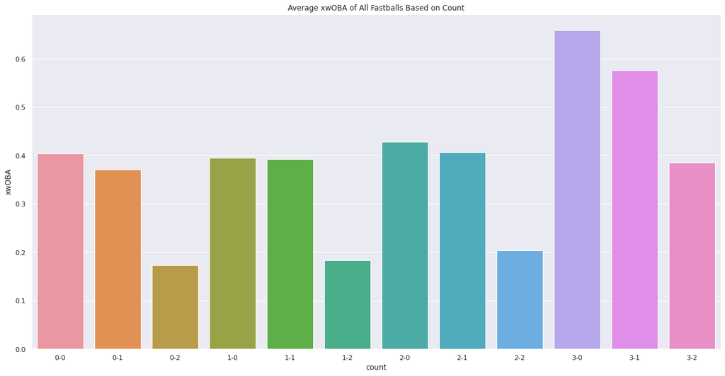

```python
#Setting figure size to make Plot bigger
plt.figure(figsize=(20,10))

#Creating Bar Plot
#fastballs.groupby('count').mean().reset_index() creates dataframe with average xwOBA for each count
sns.barplot(data=fastballs.groupby('count').mean().reset_index(), x='count', y='xwOBA')

#Add title
plt.title('Average xwOBA of All Fastballs Based on Count')
plt.show()
```

And look at that! Just like we thought, there seems to be a severe impact of xwOBA based on the count. Specifically we can see that for 0-2, 1-2, and 2-2 counts the average xwOBA is a ridiculously 0.2 or below. But for 3-0 counts and 3-1 counts the average xwOBA is above 0.55 which is ludicrous. For all the other counts the average xwOBA seems to be around 0.39.

So from this we can classify all two strike counts aside from 3-2 as pitcher counts clearly as the xwOBA is very low. Nearly every other count though seems to be a hitters count as the average xwOBA in all other counts is well above the average xwOBA of 0.320, and is above the average xwOBA from our sample of 0.342

So it seems fair to say that count has an impact on the effectiveness of a fastball, and a seemingly large impact at that, as the xwOBA varies drastically depending on the count.

However count is not the only factor that can influence fastball effectivness. An important component of any pitch is the location of it, or where it is thrown.

## Association Between Zone and xwOBA

Generally speaking pitches closer to the middle of the strike zone are easier to hit, and so we'd expect them to have higher xwOBAs on average.

Among the data we have from Statcast, one of them is zone. Statcast has divided the strike zone and its surrounding areas into 13 different zones, and these are stored in our 'zone' column. Let's plot the average xwOBA of pitches based on their zone to examine the effect location has on fastball effectivness.

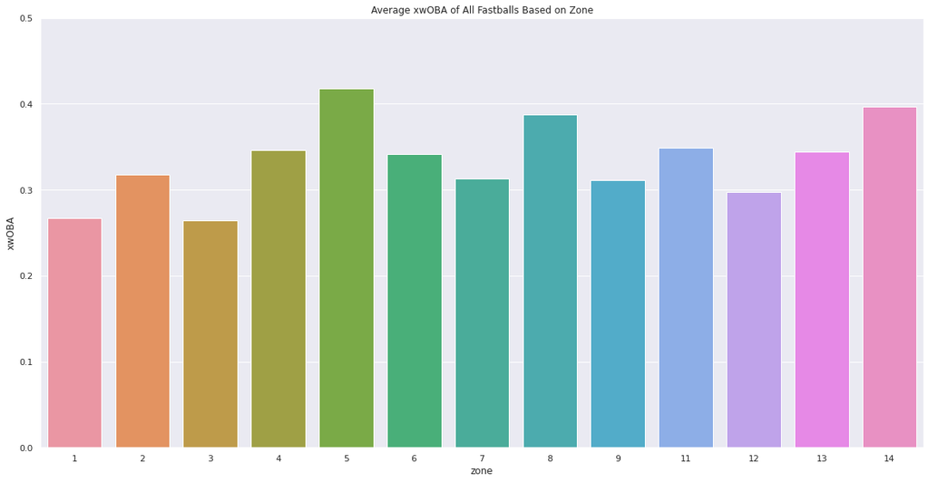

```python
#Set figure size
plt.figure(figsize=(20,10))

#Create bar plot
sns.barplot(data=fastballs.groupby('zone').mean().reset_index(), x='zone', y='xwOBA')

#Customizing range of y-axis
plt.ylim([0, 0.5])

#Add title
plt.title('Average xwOBA of All Fastballs Based on Zone')
plt.show()
```

For reference, here is a diagram of the zones, as shown from the viewpoint of the catcher

[figure not shown]

So we can see that location seems to have a large impact on xwOBA, and thus effectiveness of fastballs. However this varies depending on the type of fastball thrown. Remember there are five different kinds of fastballs that in our data set we have 4-Seam Fastballs, 2-Seam Fastballs, Cutters, Sinkers, and Split-Finger Fastballs.

## Association Between Zone and xwOBA for Each Type of Fastball

The conventional baseball wisdom as it were, is that 4-Seam Fastballs are effective when thrown high in the strike zone (zones 1-3). Whereas Sinkers and Splitters are more effective when thrown low in the strike zone (zones 7-9).

Let's replicate this bar plot, but we'll make one for each pitch separately instead, to see if the pitch type also has an impact with location on fastball effectiveness.

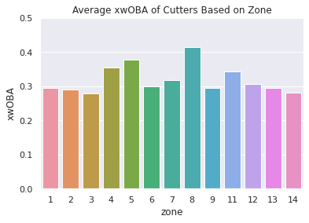

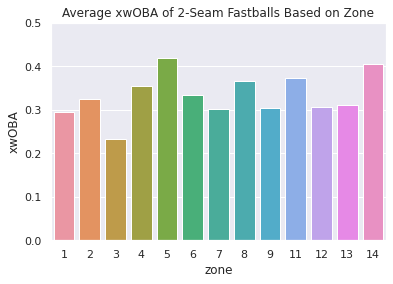

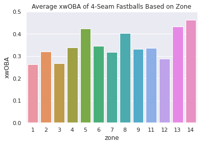

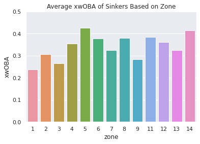

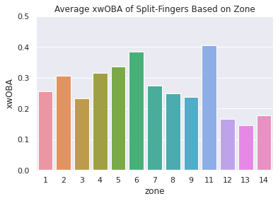

```python
#For each type of fastball
for pitch in fastballs['pitch_name'].unique():
    #Get dataframe of observations with only that pitch type
    df=fastballs[fastballs['pitch_name'] == pitch]

    #create bar plot
    ax = sns.barplot(data=df.groupby('zone').mean().reset_index(), x='zone', y='xwOBA')

    #Setting y-axis range for consistency across plots
    plt.ylim([0, 0.5])

    #Add title
    plt.title(f"Average xwOBA of {pitch}s Based on Zone")
    plt.show()
```

For the most part these Plots look the same. They all seem to show similar trends in that throwing a fastball down the middle (zone 5) is very ineffective and is generally the worst spot for a fastball. Additionally the middle of the plate in terms of width (zones 2, 5, 8) seem to fare worse than their counterparts on the edge of the strike zone at the same height (zones 1,3, 4,6, and 7,9 respectively). Another similarity between all the plots is that generally, the upper third of the strike zone is the most effective spot to throw a fastball, as compared to the other zones in the strike zone (1-9), fastballs in zones 1-3 seem to have lower xwOBAs on average than in other zones.

However there are a few subtle differences that present themselves in these plots. The most obvious is regarding Split-Fingers outside of the strike zone. For every other fastball, the most effective zone to throw it in is one of zones 1-3, which are in the strike zone. But for Split-Fingers, the most effective location is actually outside of the strikezone, in zones 12-14, and it's not particularly close either when looking at the xwOBAs by zone for the pitch.

Furthermore, Split-Fingers seem to be the only fastball for which throwing it low is a strength. Among all five fastball types, it is the only one that has an average xwOBA below 0.3 for all 5 of the low zones (7-9, 13-14).

Another interesting difference is that Cutters seem to be the only fastball that remains effective in all areas outside of the strike zone (zones 11-14). For every other pitch, at least one of these zones has an average xwOBA above 0.4, which is very poor for a pitcher. But for Cutters the highest xwOBA among zones outside the strike zone is less than 0.35, and is in zone 11, for zones 12-14 it's at or below 0.3, making cutters thrown outside of the strike zone actually effective.

So while there are plenty of general trends shown regardless of pitch type, it seems clear that pitch type and location together do have some type of influence on xwOBA and therefore the effectiveness of a fastball, and their effects are not independent of each other.

## Examining Where Each Type of Fastball is Typically Thrown

We can see that both location and pitch type play a significant role on the effectiveness of a fastball. Next let's look at where pitchers are actually throwing their fastballs. To do this we'll create a density map, showing the distribution of each pitch type. We'll also drawn in the strike zone in order to more easily discern these pitch locations.

To draw these density maps we will be using the 'plate_x' and 'plate_z' coordinate values from our Statcast data, which represent where the ball crossed the plate on each pitch. These are measured in feet and a plate_x value of zero represents a pitch that was directly over the middle of the plate horizontally. A negative plate_x indicates it was towards the third base side of home plate, and a positive towards the first base side (zones 1,4,7,11,13 and 3,6,9,12,14 respectively). A plate_z value of 0 represents a pitch that was on the ground as it crossed home plate, with a higher plate_z value indicating the pitch was higher up. Both of these are measured in feet.

To draw the strike zone we will have to guess a little bit. By MLB rules, home plate (whose width represents the strike zone) is 17 inches accross, or 1.417 feet. This means that the left edge of the strike zone is at roughly x=-0.71, and the right edge is at x=0.71. The height of the strike zone however differs from batter to batter as it is dependent on their height. However, as detailed in [this article](https://www.baseballprospectus.com/news/article/14098/spinning-yarn-the-real-strike-zone-part-2/) one of the most common ways to show a fixed height strike zone for visual displays is to set its lower edge at z=1.5 feet, and upper edge at z=3.5 feet.

For drawing the density plot we will be using Seaborn's Kernal Desnity Estimator Plot, which shows densitys of 2D data like pitch location. After making the plot we'll simply draw a rectangle at the strike zone's coordinates over it. We'll do this individually for each pitch type to see where pitchers are locating each different kind of fastball.

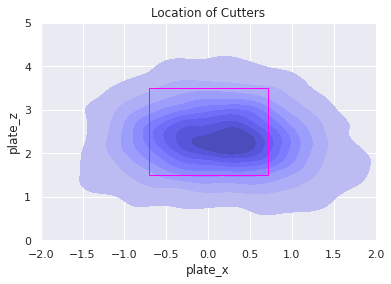

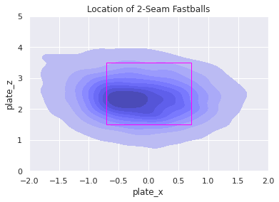

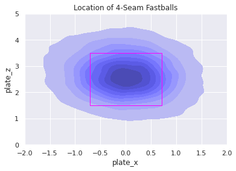

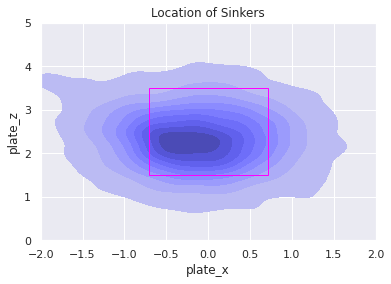

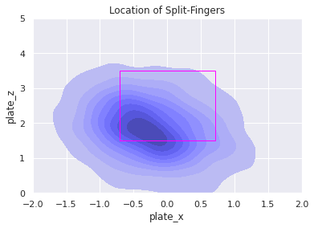

```python
#For each type of fastball
for pitch in fastballs['pitch_name'].unique():
    #Get subset of data that is only pitches of that type
    df=fastballs[fastballs['pitch_name'] == pitch]

    #make density plot
    ax = sns.kdeplot(data=df, x='plate_x', y='plate_z', shade=True, color='blue')

    #Set common plot boundaries for consistent size and shape of plots for easy comparison
    plt.xlim([-2, 2])
    plt.ylim([0, 5])

    #add in strike zone
    ax.add_patch(patches.Rectangle([-0.71, 1.5], width=1.42, height=2, fill=False, color='magenta'))

    #Add title and display
    plt.title(f"Location of {pitch}s")
    plt.show()
```

From this we can see that pitchers definitely try and locate their fastballs in different areas of the strike zone depending on what kind of fastball it is. Cutters, 2-Seam, and 4-Seam fastballs all seem to be located primarily inside the strike zone and at middle height. However for Cutters they tend to be thrown on the first base side (zone 6), 2-Seamers on the third base side (zone 4), and 4-Seamers down the middle (zone 5).

Another interesting thing that we can see is that Split-Fingers are almost exclusively thrown low in the zone, and few are thrown in or above the upper third of the strike zone. This seems to align with the Bar Plots shown earlier that Split-Fingers are most effective when thrown in the lower zones (7-9, 13-14), so clearly pitchers are aware that this fastball is most effective in these locations.

We can also see that pitchers are aware of the strengths of the 4-Seam Fastball as well. The earlier bar plot showed us that 4-Seam Fastballs are most effective when thrown up in the strike zone, and from here we can see pitchers tend to throw 4-Seam Fastballs higher than any other pitch, as it has the highest average height and maximum height in the plots shown.

These are clear signs that pitchers are aware of the strengths and weaknesses of each pitch, and tend to throw fastballs where they are most effective. With such a large set dataset there is obviously lots of variation, which is shown in the plots, but there do seem to be some clear trends and differences.

## Association Between Count and Zone, and xwOBA for Each Type of Fastball

We know that the count also has a lot to do with the effectiveness of each pitch. Specifically we saw in our bar plots earlier, that in any count with two strikes (excluding the 3-2 count), the average xwOBA of hitters decreases drastically compared to in other counts. Let's see if location also plays a role in the effectivness of a two strike pitch.

To do this let's replicate our bar plots from before, but only include pitches thrown with two strikes. Additionally we'll create a plot for each type of fastball in order to examine how count and location impact each type of fastball differently.

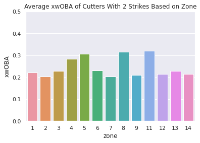

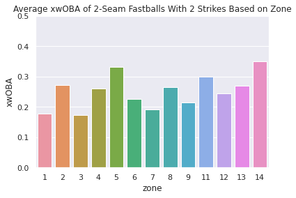

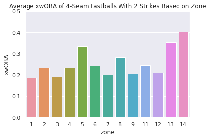

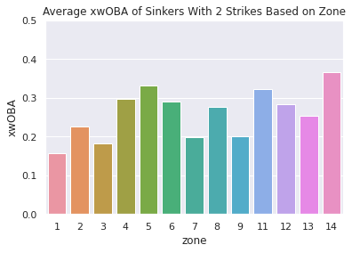

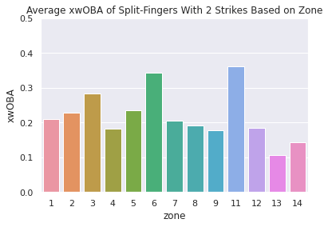

```python
#For each type of fastball
for pitch in fastballs['pitch_name'].unique():
    #Get dataframe of observations with only that pitch type AND two strikes
    df=fastballs[(fastballs['pitch_name'] == pitch) & (fastballs['strikes'] == 2)]

    #create bar plot
    ax = sns.barplot(data=df.groupby('zone').mean().reset_index(), x='zone', y='xwOBA')

    #Setting y-axis range for consistency across plots
    plt.ylim([0, 0.5])

    #Add title
    plt.title(f"Average xwOBA of {pitch}s With 2 Strikes Based on Zone")
    plt.show()
```

Just like before, we can see that with two strikes, the average xwOBA is significantly lower compared to when there is not two strikes. We can also see some differences in the effectiveness of each pitch based on the zone its in.

We can also see that 4-Seam Fastballs are unique in that they are the only fastball that has an average xwOBA below 0.25 in each of the high zones (1-3, 11-12), and this seems to be the strength of the 4-Seam Fastball.

We can also see that, just like before, pitches down the middle (zone 5) are among the least effective fastballs based on xwOBA, so there are still some common trends as well.

## Examining Where Each Type of Fastball is Typically Thrown with 2 Strikes

Now that we know where each fastball is most effective, let's recreate our Kernel Density Estimator Plots from before, using only pitches with two strikes, to see where pitchers are throwing each pitch with two strikes.

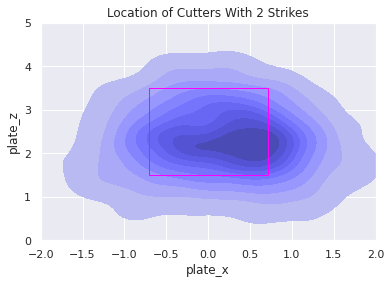

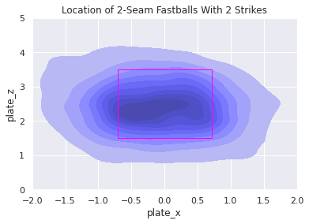

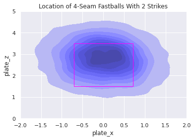

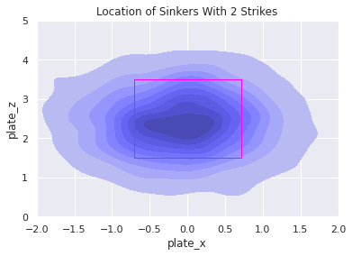

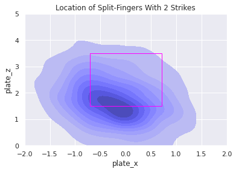

```python
#For each type of fastball
for pitch in fastballs['pitch_name'].unique():
    #Get subset of data of only pitches of that type AND with 2 strikes
    df=fastballs.loc[(fastballs['pitch_name'] == pitch) & (fastballs['strikes'] == 2)]

    #Make plot
    ax = sns.kdeplot(data=df, x='plate_x', y='plate_z', shade=True, color='blue')

    #Setting common boundaries of plots
    plt.xlim([-2, 2])
    plt.ylim([0, 5])

    #draw strikezone
    ax.add_patch(patches.Rectangle([-0.71, 1.5], width=1.42, height=2, fill=False, color='magenta'))

    #Add title and display plot
    plt.title(f"Location of {pitch}s With 2 Strikes")
    plt.show()
```

Ok great, we can clearly see some trends! Split-Fingers are being thrown very low in the zone with 2 strikes, and 4-Seam Fastballs are being thrown up in the zone with two strikes. This matches up with the effectiveness of each pitch and so we can see that pitchers are definitely aware of the strengths and weaknesses of each fastball and are tending to utilize them to the best of their abilities.

And just like before we can see that cutters are being thrown on the first base side of the plate, while 2-Seam Fastballs are being thrown on the opposite side. So the trends in location being shown on pitches with 2 strikes tend to be the same as the ones shown in general, just a bit more exaggerated.

## Re-Examining Association Between Location and xwOBA Using Heatmaps

We saw earlier that location has a seemingly large impact on fastball effectiveness, both overall and for each type of fastball. However our analysis of this was a bit elementary as we just used pre-provided Statcast zones. And while it provided some useful insight and information it would be a lot better if we could visually **show** the location so we could more easily identify trends.

Luckily we can do this! To do so we'll create a heatmap, showing the average xwOBA of all fastballs thrown in certain areas. These plots should back up what we could already see from our bar plots earlier, but will be much easier to visualize.

To start, we'll have to reformat our data so that it matches the input desired for the heatmap.

Currently our data is in a table where each **row** represents a single observation, to create a heatmap we need each **cell** to represent an observation. Moreover, these cells need to be spatially oriented in the way we want the heatmap to be spatially oriented this.

This is just a fancy way of saying we need to create a table where each entry is the average xwOBA for a certain location. And the top left location's average xwOBA should be in the top left (row 1 column 1) of the table. Similarly, the bottom left location's average xwOBA should be in the bottom left cell of the table, etc.

The locations we want to look at will be zones 1-9, each of which is a rectangle that is 1/9 of the strike zone. We'll also want zones of the same size directly outside the strike zone to represent the areas where pitchers just missed the strike zone. Outside of these zones, we'll just have large areas to capture all remaining pitches that missed the strike zone by a lot. So we'll need one cell in our new table for each of these zones.

To begin we'll need to create custom intervals to group each x and z pitch coordinate into, so we can figure out which location it belongs in.

```python
#calculating one-third the width and height of the strike zone
zone_third_hz = 1.42 / 3
zone_third_vt = 2 / 3

#list of tuples that reprsent box boundaries
#split plate horizontally into thirds. Add boxes of same width (zone_third_hz)...
#...on each side to represent pitches that just missed strike zone
#Add in borders that were way too far off as well to capture pitches that missed by a ton

#begin with the left tuple to capture pitches that missed by a ton horizontally to the left
tups = [(-10, -0.71 - zone_third_hz)]

#add in 5 tuples of width zone_third_hz (1/3 width of strike zone) to get pitches that just missed, or were in strike zone
for i in range(5):
    start = -0.71 + zone_third_hz*(i - 1)
    tups.append((start, start + zone_third_hz))

#lastly add in tuple that reprseents pitches that missed by a ton horizontally to the right
tups.append((0.71 + zone_third_hz, 5))

#Create actual interval cutoff bins from these tuples
x_bins = pd.IntervalIndex.from_tuples(tups, closed='left')


#Now do the same thing but for the height of the strike zone instead of width

#begin with tuple for range of pitches that missed way too low
tups = [(-5, 1.5 - zone_third_vt)]

#then next 5 tuples are of range zone_third_vt (1/3 height of strike zone) to get pitches that just missed, or were in strike zone
for i in range(5):
    start = 1.5 + zone_third_vt*(i - 1)
    tups.append((start, start + zone_third_vt))

#lastly add in final tuple range to represent pitches that missed way too high
tups.append((3.5 + zone_third_vt, 10))

#Create actual interval cutoff bins from these tuples
z_bins = pd.IntervalIndex.from_tuples(tups, closed='left')

#group each pitch by it's x and z coordinates (the interval ranges are the ones we created)
fastballs['x_group'] = pd.cut(fastballs['plate_x'], bins=x_bins)
fastballs['z_group'] = pd.cut(fastballs['plate_z'], bins=z_bins)
```

Now that we've assigned each pitch to a location group for it's x and z coordinate (and thus a 2D group) let's create a new dataframe that will store the average xwOBA of all fastballs for each 2D group.

```python
#Get the average xwOBA for each x,z group
grouped = fastballs.groupby(['x_group', 'z_group']).mean()['xwOBA']
grouped
```

```
x_group                                     z_group
[-10.0, -1.1833333333333333)                [-5.0, 0.8333333333333334)                 0.615556
                                            [0.8333333333333334, 1.5)                  0.477874
                                            [1.5, 2.1666666666666665)                  0.423925
                                            [2.1666666666666665, 2.833333333333333)    0.415779
                                            [2.833333333333333, 3.4999999999999996)    0.496089
                                            [3.5, 4.166666666666667)                   0.664180
                                            [4.166666666666667, 10.0)                  0.679281
[-1.1833333333333333, -0.71)                [-5.0, 0.8333333333333334)                 0.399900
                                            [0.8333333333333334, 1.5)                  0.372920
                                            [1.5, 2.1666666666666665)                  0.279768
                                            [2.1666666666666665, 2.833333333333333)    0.287887
                                            [2.833333333333333, 3.4999999999999996)    0.270122
                                            [3.5, 4.166666666666667)                   0.372837
                                            [4.166666666666667, 10.0)                  0.492789
[-0.71, -0.23666666666666664)               [-5.0, 0.8333333333333334)                 0.362677
                                            [0.8333333333333334, 1.5)                  0.326837
                                            [1.5, 2.1666666666666665)                  0.335610
                                            [2.1666666666666665, 2.833333333333333)    0.359531
                                            [2.833333333333333, 3.4999999999999996)    0.272926
                                            [3.5, 4.166666666666667)                   0.219122
                                            [4.166666666666667, 10.0)                  0.381890
[-0.23666666666666664, 0.2366666666666667)  [-5.0, 0.8333333333333334)                 0.384474
                                            [0.8333333333333334, 1.5)                  0.347853
                                            [1.5, 2.1666666666666665)                  0.383356
                                            [2.1666666666666665, 2.833333333333333)    0.425853
                                            [2.833333333333333, 3.4999999999999996)    0.316785
                                            [3.5, 4.166666666666667)                   0.216514
                                            [4.166666666666667, 10.0)                  0.368828
[0.2366666666666667, 0.71)                  [-5.0, 0.8333333333333334)                 0.492673
                                            [0.8333333333333334, 1.5)                  0.398397
                                            [1.5, 2.1666666666666665)                  0.327285
                                            [2.1666666666666665, 2.833333333333333)    0.358166
                                            [2.833333333333333, 3.4999999999999996)    0.276215
                                            [3.5, 4.166666666666667)                   0.246851
                                            [4.166666666666667, 10.0)                  0.314964
[0.71, 1.1833333333333333)                  [-5.0, 0.8333333333333334)                 0.507556
                                            [0.8333333333333334, 1.5)                  0.433567
                                            [1.5, 2.1666666666666665)                  0.285452
                                            [2.1666666666666665, 2.833333333333333)    0.271953
                                            [2.833333333333333, 3.4999999999999996)    0.250242
                                            [3.5, 4.166666666666667)                   0.311272
                                            [4.166666666666667, 10.0)                  0.531000
[1.1833333333333333, 5.0)                   [-5.0, 0.8333333333333334)                 0.657794
                                            [0.8333333333333334, 1.5)                  0.601281
                                            [1.5, 2.1666666666666665)                  0.497701
                                            [2.1666666666666665, 2.833333333333333)    0.411708
                                            [2.833333333333333, 3.4999999999999996)    0.482881
                                            [3.5, 4.166666666666667)                   0.611526
                                            [4.166666666666667, 10.0)                  0.654000
Name: xwOBA, dtype: float64
```

What we've created unforunately is not a dataframe. It's instead a Series (think of it as a 1-dimensional dataframe or table). We have 1 column of values, the average xwOBA for each group, and 2 sets of indexes (1 for each coordinate grouping). We can easily convert this into a dataframe by reseting the indices. This will create 2 new columns, one for each of our indices, and will put each entry into it's own row.

However we want each entry to be in it's cell and not take up an entire row. So to achieve this we will pivot this new dataframe on the z_group. What this will do is make the column called z_group into an index, this way each cell will correspond to a single z_group (the row) and a single x_group (the column), and we'll have our data in the spatial format we want!

```python
#Create dataframe from the grouped data
grouped = grouped.reset_index().pivot(index='z_group', columns='x_group', values='xwOBA')
grouped
```

| x_group z_group | [-10.0, -1.1833333333333333) | [-1.1833333333333333, -0.71) | [-0.71, -0.23666666666666664) | [-0.23666666666666664, 0.2366666666666667) | [0.2366666666666667, 0.71) | [0.71, 1.1833333333333333) | [1.1833333333333333, 5.0) |
| --- | --- | --- | --- | --- | --- | --- | --- |
| [-5.0, 0.8333333333333334) | 0.615556 | 0.399900 | 0.362677 | 0.384474 | 0.492673 | 0.507556 | 0.657794 |
| [0.8333333333333334, 1.5) | 0.477874 | 0.372920 | 0.326837 | 0.347853 | 0.398397 | 0.433567 | 0.601281 |
| [1.5, 2.1666666666666665) | 0.423925 | 0.279768 | 0.335610 | 0.383356 | 0.327285 | 0.285452 | 0.497701 |
| [2.1666666666666665, 2.833333333333333) | 0.415779 | 0.287887 | 0.359531 | 0.425853 | 0.358166 | 0.271953 | 0.411708 |
| [2.833333333333333, 3.4999999999999996) | 0.496089 | 0.270122 | 0.272926 | 0.316785 | 0.276215 | 0.250242 | 0.482881 |
| [3.5, 4.166666666666667) | 0.664180 | 0.372837 | 0.219122 | 0.216514 | 0.246851 | 0.311272 | 0.611526 |
| [4.166666666666667, 10.0) | 0.679281 | 0.492789 | 0.381890 | 0.368828 | 0.314964 | 0.531000 | 0.654000 |

Ok that looks a lot better except for one thing. We need our data to be oriented in the same way the heat map should display it. So the top left cell in the dataframe will be the top left cell in the heatmap. Currently our top row of cells have the lowest z_group, and the bottom row of cells has the highest z_group. In other words our data is upside down. To fix this we simply need to reverse our rows. We can easily do this by reindexing, which will switch the order of our indices which are our z_groups.

```python
#Reverse the order of the z_group so that pitches that were higher are at the top of the dataframe
#(Should be spatially oriented correctly)
grouped = grouped.reindex(index=grouped.index[::-1])
grouped
```

| x_group z_group | [-10.0, -1.1833333333333333) | [-1.1833333333333333, -0.71) | [-0.71, -0.23666666666666664) | [-0.23666666666666664, 0.2366666666666667) | [0.2366666666666667, 0.71) | [0.71, 1.1833333333333333) | [1.1833333333333333, 5.0) |
| --- | --- | --- | --- | --- | --- | --- | --- |
| [4.166666666666667, 10.0) | 0.679281 | 0.492789 | 0.381890 | 0.368828 | 0.314964 | 0.531000 | 0.654000 |
| [3.5, 4.166666666666667) | 0.664180 | 0.372837 | 0.219122 | 0.216514 | 0.246851 | 0.311272 | 0.611526 |
| [2.833333333333333, 3.4999999999999996) | 0.496089 | 0.270122 | 0.272926 | 0.316785 | 0.276215 | 0.250242 | 0.482881 |
| [2.1666666666666665, 2.833333333333333) | 0.415779 | 0.287887 | 0.359531 | 0.425853 | 0.358166 | 0.271953 | 0.411708 |
| [1.5, 2.1666666666666665) | 0.423925 | 0.279768 | 0.335610 | 0.383356 | 0.327285 | 0.285452 | 0.497701 |
| [0.8333333333333334, 1.5) | 0.477874 | 0.372920 | 0.326837 | 0.347853 | 0.398397 | 0.433567 | 0.601281 |
| [-5.0, 0.8333333333333334) | 0.615556 | 0.399900 | 0.362677 | 0.384474 | 0.492673 | 0.507556 | 0.657794 |

Ok great, now our data is in the correct format for a heatmap! Each cell represents the average xwOBA of fastballs in a certain location, and the cells are correctly spatially oriented! Let's create that heatmap now so we can more clearly see which areas fastballs are most and least effective.

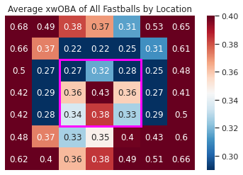

```python
#Creating heatmap
#annot=True displays average xwOBA of each cell
#vmin and vmax are chosen because per Fangraphs, 0.29 is terrible xwOBA and 0.4 is excellent xwOBA (for hitters, opposite for pitchers)
ax = sns.heatmap(grouped, annot=True, cmap='RdBu_r', vmin=0.29, vmax=0.4)

#Drawing rectangle for strike zone
ax.add_patch(patches.Rectangle((2, 2), 3, 3, fill=False, edgecolor='magenta', lw=3))

plt.title('Average xwOBA of All Fastballs by Location')

#Turning off  axis to hide the groups from displaying. Otherwise looks like a jarbled mess
ax.axis('off')

plt.show()
```

We can see from the heatmap a lot of very clear patterns that weren't as clear from the bar plots earlier.

The first is that throwing pitches well outside of the zone (represented by all of the outside boxes) is generally a bad idea as they have the highest average xwOBAs. This is likely because the pitchers are so far out of the zone that the batter doesn't swing at them and these pitches result in walks. So these pitches seem to be ineffective. The only exceptions to this are pitches very low in the zone and very up in the zone. These are likely explained by Splitters and 4-Seamers respectively as we saw earlier that their strengths are low and up in the zone respectively, and they might make hitters more likely to chase these pitches they otherwise would not.

We can also see that pitches directly in the middle of the strike zone also get hit really hard, and fastballs thrown down the middle are not going to be very effective pitches generally.

The heatmap shows fairly clearly that fastballs are best utilized near the borders of the strike zone, and slightly up, as those locations are where hitters have the lowest average xwOBAs.

## Re-Examining Association Between Location and xwOBA for Each Type of Fastball Using Heatmaps

All of this is great and all but we saw some clear differences between a fastballs effectivness in a given location depending on the type of fastball that it is. So let's recreate this heatmap, but make one for each individual type of fastball in order to examine this.

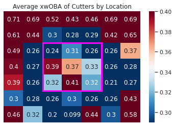

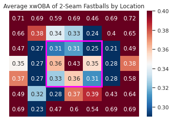

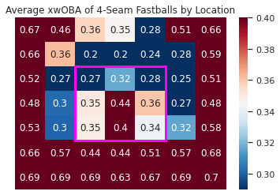

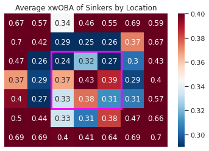

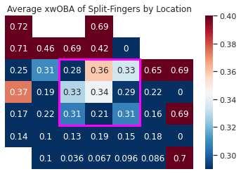

```python
#For each type of fastball
for pitch in fastballs['pitch_name'].unique():
    #Get subset of data that is only that pitch type
    df = fastballs[fastballs['pitch_name'] == pitch]

    #calculate the average xwOBA of these pitches for each location
    grouped = df.groupby(['x_group', 'z_group']).mean()['xwOBA']

    #Reconfigure the dataframe to correctly spatially orient the values
    grouped = grouped.reset_index().pivot(index='z_group', columns='x_group', values='xwOBA')
    grouped = grouped.reindex(index=grouped.index[::-1])

    #Create heat map and draw strikezone
    ax = sns.heatmap(grouped, annot=True, cmap='RdBu_r', vmin=0.29, vmax=0.4)
    ax.add_patch(patches.Rectangle((2, 2), 3, 3, fill=False, edgecolor='magenta', lw=3))

    #Add title and turn off axis to make plot readable and display
    plt.title(f'Average xwOBA of {pitch}s by Location')
    ax.axis('off')
    plt.show()
```

Looking at these plots we can see, much like we did before with the individual bar plots, distinct trends of effectiveness for each fastball.

We can see that Cutters seem to be very effective anywhere around the strikezone and only seem to get hit hard when thrown near the middle of the plate. The only other areas where they are ineffective are on pitches that were not particularly close to the strike zone, especially one that missed by a lot up, on pitches that missed by a lot down and are near the dirt, they seem to stay fairly effective.

On the other hand, 2-Seam Fastballs seem to be ineffective whenever they miss the strike zone by a large margin, regarldess of where it is. When 2-Seam Fastballs are thrown in the strike zone they tend to fair generally ok but are not great. The real strength of the 2-Seam Fastball seems to be when it is thrown just outside the zone horizontally, as in all 6 zones where it only missed by a small margin horizontally it had an average xwOBA of below 0.3.

Sinkers seem to profile similarly to 2-Seam Fastballs based on the heatmap. And this makes sense, as often times the two are mixed up and some use the term interchangeably. Sinkers do not fare well unless they are close to the strike zone, and seem to be most effective when just outside of the strike zone horizontally.

So from these individual heatmaps we can clearly see that each fastball has its own strengths and weaknesses regarding location and the pitch type and location together have very heavy implications on the effectiveness of a fastball.